# 森林覆盖类型数据 分析过程

```python
# 导入数据分析包
import pandas as pd
import numpy as np

# 避免不必要的警告，使演示整洁
import warnings
warnings.filterwarnings('ignore')
```

## 1. 数据抽取

```python
# 从数据文件中导入数据
dataset = pd.read_csv("data/train.csv")

# 删除第一列“Id”，因为它只是个序列号，对于数据分析与结果预测没有任何作用
dataset = dataset.iloc[:,1:]
```

## 2. 数据探索分析

```python
# 数据整体轮廓
# 数据大小规格

print(dataset.shape)
```

```
(15120, 55)
```

```python
# 统计描述

pd.set_option('display.max_columns', None)
print(dataset.describe())
```

```
          Elevation        Aspect         Slope  \
count  15120.000000  15120.000000  15120.000000
mean    2749.322553    156.676653     16.501587
std      417.678187    110.085801      8.453927
min     1863.000000      0.000000      0.000000
25%     2376.000000     65.000000     10.000000
50%     2752.000000    126.000000     15.000000
75%     3104.000000    261.000000     22.000000
max     3849.000000    360.000000     52.000000

       Horizontal_Distance_To_Hydrology  Vertical_Distance_To_Hydrology  \
count                      15120.000000                    15120.000000
mean                         227.195701                       51.076521
std                          210.075296                       61.239406
min                            0.000000                     -146.000000
25%                           67.000000                        5.000000
50%                          180.000000                       32.000000
75%                          330.000000                       79.000000
max                         1343.000000                      554.000000

       Horizontal_Distance_To_Roadways  Hillshade_9am  Hillshade_Noon  \
count                     15120.000000   15120.000000    15120.000000
mean                       1714.023214     212.704299      218.965608
std                        1325.066358      30.561287       22.801966
min                           0.000000       0.000000       99.000000
25%                         764.000000     196.000000      207.000000
50%                        1316.000000     220.000000      223.000000
75%                        2270.000000     235.000000      235.000000
max                        6890.000000     254.000000      254.000000

       Hillshade_3pm  Horizontal_Distance_To_Fire_Points  Wilderness_Area1  \
count   15120.000000                        15120.000000      15120.000000
mean      135.091997                         1511.147288          0.237897
std        45.895189                         1099.936493          0.425810
min         0.000000                            0.000000          0.000000
25%       106.000000                          730.000000          0.000000
50%       138.000000                         1256.000000          0.000000
75%       167.000000                         1988.250000          0.000000
max       248.000000                         6993.000000          1.000000

```

[output cut: 74 more lines]

```
min        0.000000      0.000000      0.000000      0.000000      0.000000
25%        0.000000      0.000000      0.000000      0.000000      0.000000
50%        0.000000      0.000000      0.000000      0.000000      0.000000
75%        0.000000      0.000000      0.000000      0.000000      0.000000
max        1.000000      1.000000      1.000000      1.000000      1.000000

        Soil_Type37   Soil_Type38   Soil_Type39   Soil_Type40    Cover_Type
count  15120.000000  15120.000000  15120.000000  15120.000000  15120.000000
mean       0.002249      0.048148      0.043452      0.030357      4.000000
std        0.047368      0.214086      0.203880      0.171574      2.000066
min        0.000000      0.000000      0.000000      0.000000      1.000000
25%        0.000000      0.000000      0.000000      0.000000      2.000000
50%        0.000000      0.000000      0.000000      0.000000      4.000000
75%        0.000000      0.000000      0.000000      0.000000      6.000000
max        1.000000      1.000000      1.000000      1.000000      7.000000
```

- 分析结论：
  1. 没有缺失值 所有特征的计数都是15120
  2. Wilderness_Area 和 Soil_Type 是热门编码
  3. Soil_Type7 和 Soil_Type15 统计全为0 可以被移除

```python
# 数据分布的偏斜度

print(dataset.skew())
```

```
Elevation                               0.075640
Aspect                                  0.450935
Slope                                   0.523658
Horizontal_Distance_To_Hydrology        1.488052
Vertical_Distance_To_Hydrology          1.537776
Horizontal_Distance_To_Roadways         1.247811
Hillshade_9am                          -1.093681
Hillshade_Noon                         -0.953232
Hillshade_3pm                          -0.340827
Horizontal_Distance_To_Fire_Points      1.617099
Wilderness_Area1                        1.231244
Wilderness_Area2                        5.228781
Wilderness_Area3                        0.324594
Wilderness_Area4                        0.825798
Soil_Type1                              6.294716
Soil_Type2                              4.617019
Soil_Type3                              3.575995
Soil_Type4                              3.872721
Soil_Type5                              9.416209
Soil_Type6                              4.506716
Soil_Type7                              0.000000
Soil_Type8                            122.963409
Soil_Type9                             38.849712
Soil_Type10                             2.055410
Soil_Type11                             5.854551
Soil_Type12                             7.977205
Soil_Type13                             5.366836
Soil_Type14                             9.300318
Soil_Type15                             0.000000
Soil_Type16                            11.387050
Soil_Type17                             4.663945
Soil_Type18                            15.781426
Soil_Type19                            18.048915
Soil_Type20                            10.286265
Soil_Type21                            30.695081
Soil_Type22                             6.391991
Soil_Type23                             4.126701
Soil_Type24                             7.474026
Soil_Type25                           122.963409
Soil_Type26                            16.645076
Soil_Type27                            31.704896
Soil_Type28                            40.955261
Soil_Type29                             2.967651
Soil_Type30                             4.231913
Soil_Type31                             6.524804
Soil_Type32                             4.354839
Soil_Type33                             4.646742
Soil_Type34                            26.161230
Soil_Type35                            12.052838
Soil_Type36                            38.849712
Soil_Type37                            21.018939
Soil_Type38                             4.221771
Soil_Type39                             4.479186
Soil_Type40                             5.475256
Cover_Type                              0.000000
dtype: float64
```

- 分析结论：
  1. 越接近0 表示偏斜度越小
  2. 有几个土壤类型的偏斜度很大 Soil_Type8 Soil_Type25

```python
# 统计每种森林类型的出现次数

dataset.groupby('Cover_Type').size()
```

```
Cover_Type
1    2160
2    2160
3    2160
4    2160
5    2160
6    2160
7    2160
dtype: int64
```

- 分析结论：可以看出所有类别出现频次都相等，所提供的数据很均衡，无需再平衡

```python
# 相关性分析
# 获取高相关性特性对

# 设置参与相关性判断的特征个数
size = 10

# 创建只有指定数据特征的数据集
data=dataset.iloc[:,:size]

# 获取所有列的名称
cols=data.columns

# 计算所有组合的皮尔逊系数
data_corr = data.corr()

# Set the threshold to select only only highly correlated attributes
# 设置阈值 仅选择较高的相关性
threshold = 0.5

# 高于阈值的相关性列表
corr_list = []

# 获取高相关性的特征对
for i in range(0,size):
    for j in range(i+1,size): # 避免重复
        if (data_corr.iloc[i,j] >= threshold and data_corr.iloc[i,j] < 1) or (data_corr.iloc[i,j] < 0 and data_corr.iloc[i,j] <= -threshold):
            corr_list.append([data_corr.iloc[i,j],i,j]) # 存储相关性和对应的列索引

# 对获取到的特征对排序
s_corr_list = sorted(corr_list,key=lambda x: -abs(x[0]))

# 打印相关性及列名
for v,i,j in s_corr_list:
    print ("%s and %s = %.2f" % (cols[i],cols[j],v))
```

```
Hillshade_9am and Hillshade_3pm = -0.78
Horizontal_Distance_To_Hydrology and Vertical_Distance_To_Hydrology = 0.65
Aspect and Hillshade_3pm = 0.64
Hillshade_Noon and Hillshade_3pm = 0.61
Slope and Hillshade_Noon = -0.61
Aspect and Hillshade_9am = -0.59
Elevation and Horizontal_Distance_To_Roadways = 0.58
```

- 分析结论：以上特征对有很强的相关性，可以通过PCA减少特征集

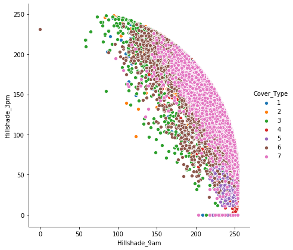

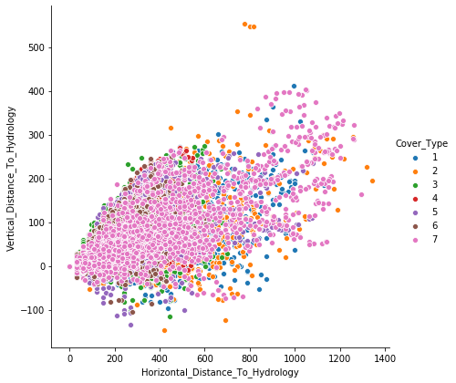

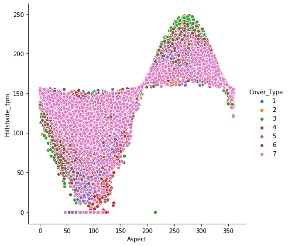

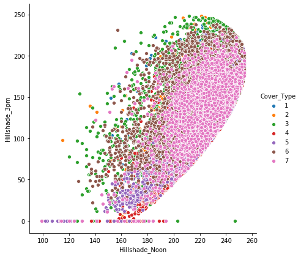

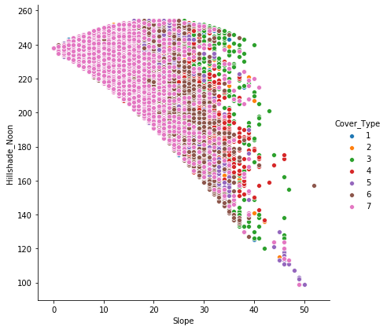

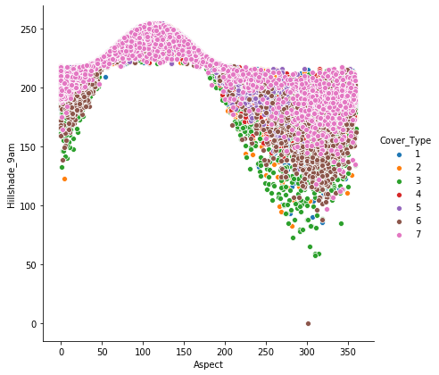

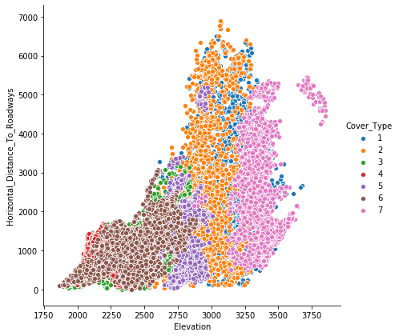

```python
# 数据散点图

# 导入绘图包
import seaborn as sns
import matplotlib.pyplot as plt
%matplotlib inline

# 仅绘制高相关性特征对的散点图
for v,i,j in s_corr_list:
    sns.pairplot(dataset, hue="Cover_Type", size=6, x_vars=cols[i],y_vars=cols[j])
    plt.show()
```

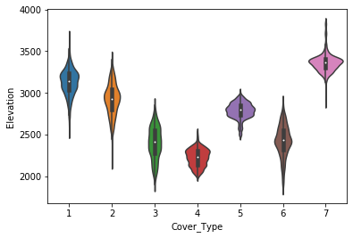

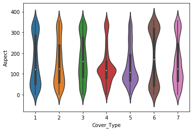

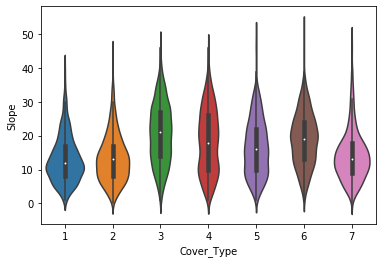

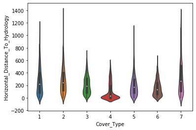

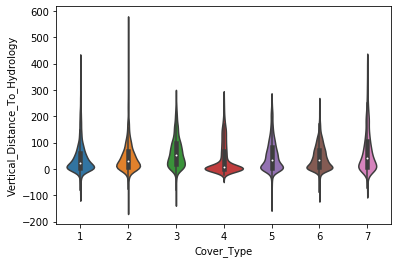

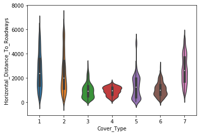

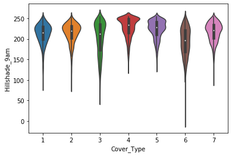

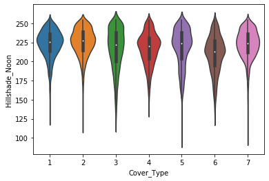

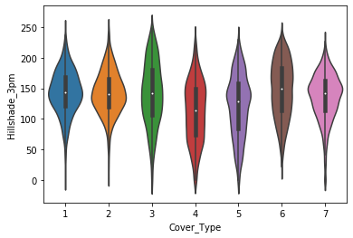

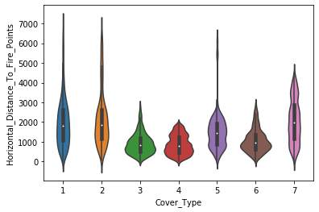

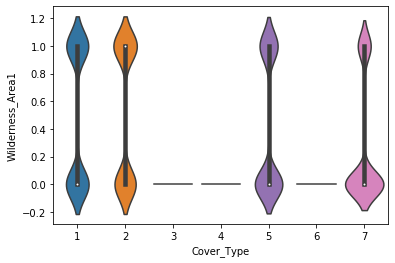

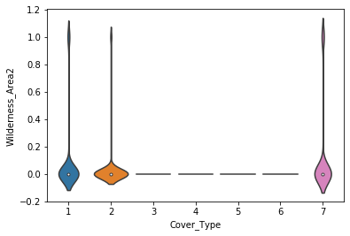

[42 more figures not shown]

```python
# 数据特征小提琴图

# 所有特征的名称
cols = dataset.columns

# 数据特征个数（即减去目标值）
size = len(cols)-1

# x轴为森林覆盖类型
x = cols[size]

# y轴为各特征
y = cols[0:size]

# 绘制所有特征关于森林覆盖类型的小提琴图
for i in range(0,size):
    sns.violinplot(data=dataset,x=x,y=y[i])
    plt.show()
```

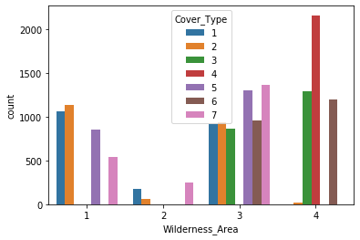

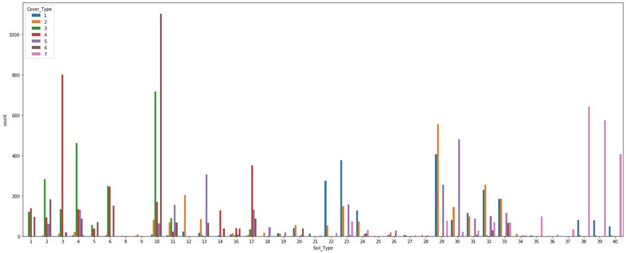

```python
# 将一个类别的热键变量组合成一个单独的变量
# 4种荒野地区类型 Wilderness_Area
# 40种土壤类型 Soil_Type

# 所有特征的名称
cols = dataset.columns

# 数据的行数和列数
r,c = dataset.shape

# 创建一个新的数据集，包含原有行数，指定编码类别为一列，最后是目标值
data = pd.DataFrame(index=np.arange(0, r),columns=['Wilderness_Area','Soil_Type','Cover_Type'])

# 对每一行数据选取第一个为1作为代表
for i in range(0, r):
    w=0;
    s=0;
    # 类别1 Wilderness_Area
    for j in range(10,14):
        if (dataset.iloc[i,j] == 1):
            w=j-9
            break
    # 类别2 Soil_Type
    for k in range(14,54):
        if (dataset.iloc[i,k] == 1):
            s=k-13
            break
    data.iloc[i]=[w,s,dataset.iloc[i,c-1]]

# 类别1 Wilderness_Area
sns.countplot(x="Wilderness_Area", hue="Cover_Type", data=data)
plt.show()
# 类别2 Soil_Type
plt.rc("figure", figsize=(25, 10))
sns.countplot(x="Soil_Type", hue="Cover_Type", data=data)
plt.show()
```

- 分析结论：
  1. `荒野类型4`对应有许多`覆盖类型4`的存在，可以作为一个较好的区分依据
  2. 相对而言，`荒野类型3`就没有太好区分度了
  3. `土壤类型10`对应有许多`覆盖类型6`的存在，可以作为较好区分依据
  4. `土壤类型`某些类别可以提供一定的区分，因为某些类别计数高

## 3. 数据预处理

### 3.1 数据清洗

```python
# 删除不必要的特征

# 被删除特征列表
rem = []

# 添加常量列，因为它们对预测过程没有帮助
for c in dataset.columns:
    if dataset[c].std() == 0: # 标准偏差为零
        rem.append(c)

# 删除特征
dataset.drop(rem,axis=1,inplace=True)

print(rem)
```

```
['Soil_Type7', 'Soil_Type15']
```

### 3.2 数据预处理

```python
# 获得数据行数和列数
r, c = dataset.shape

# 获取特征名称
cols = dataset.columns

# 创建包含特征索引值的列表
i_cols = []
for i in range(0,c-1):
    i_cols.append(i)

# 所有特征的权重数组
ranks = []

# 仅提取值
array = dataset.values

# X为特征值 Y为目标值
X = array[:,0:(c-1)]
Y = array[:,(c-1)]

# 验证块大小
val_size = 0.3

# 在所有实验中使用相同的种子，以便使用相同的数据块进行验证
seed = 45

# 将数据集切分成训练集和测试集 7:3
from sklearn.model_selection import train_test_split
X_train, X_val, Y_train, Y_val = train_test_split(X, Y, test_size=val_size, random_state=seed)
```

## 4. 模型构建

```python
from sklearn.metrics import accuracy_score # 导入正确率计算函数
from sklearn.metrics import confusion_matrix # 导入混淆矩阵函数

# 编写混淆矩阵的可视化函数
def cm_plot(y, yp):

  cm = confusion_matrix(y, yp) # 混淆矩阵
  plt.matshow(cm, cmap=plt.cm.Greens) # 画混淆矩阵图，配色风格使用cm.Greens
  plt.colorbar() # 颜色标签

  for x in range(len(cm)): # 数据标签
    for y in range(len(cm)):
      plt.annotate(cm[x,y], xy=(x, y), horizontalalignment='center', verticalalignment='center')

  plt.ylabel('True label') # 坐标轴标签
  plt.xlabel('Predicted label') # 坐标轴标签
  return plt
```

### 4.1 随机森林分类算法构建模型

```python
from sklearn.ensemble import RandomForestClassifier

# 设置100棵决策树
first_forest = RandomForestClassifier(
    n_estimators=100, random_state=45, n_jobs=4)
```

```python
%%time
first_forest.fit(X_train, Y_train)
```

```
CPU times: user 4.87 s, sys: 50.7 ms, total: 4.92 s
Wall time: 1.46 s
```

```
RandomForestClassifier(bootstrap=True, class_weight=None, criterion='gini',
                       max_depth=None, max_features='auto', max_leaf_nodes=None,
                       min_impurity_decrease=0.0, min_impurity_split=None,
                       min_samples_leaf=1, min_samples_split=2,
                       min_weight_fraction_leaf=0.0, n_estimators=100, n_jobs=4,
                       oob_score=False, random_state=45, verbose=0,
                       warm_start=False)
```

```python
# 预测目标值
rf_forest_val_pred = first_forest.predict(X_val)

# 计算模型预测的正确率
rf_forest_acc = accuracy_score(Y_val, rf_forest_val_pred)
print("随机森林分类模型预测的正确率：" + str(rf_forest_acc))
```

```
随机森林分类模型预测的正确率：0.8597883597883598
```

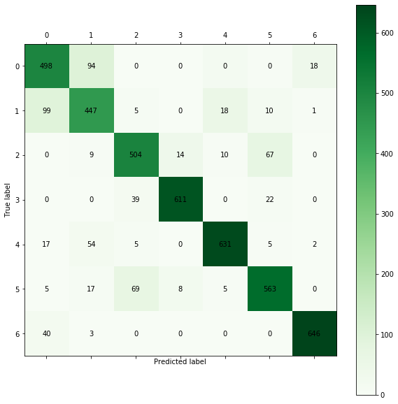

```python
# 显示混淆矩阵
cm_plot(Y_val, rf_forest_val_pred).show()
```

### 4.2 LightGBM分类算法构建模型

```python
from lightgbm import LGBMClassifier

# 新建LGBM分类器
lgb_clf = LGBMClassifier(random_state=45)
```

```python
%%time
lgb_clf.fit(X_train, Y_train)
```

```
CPU times: user 11.4 s, sys: 115 ms, total: 11.5 s
Wall time: 3.06 s
```

```
LGBMClassifier(boosting_type='gbdt', class_weight=None, colsample_bytree=1.0,
               importance_type='split', learning_rate=0.1, max_depth=-1,
               min_child_samples=20, min_child_weight=0.001, min_split_gain=0.0,
               n_estimators=100, n_jobs=-1, num_leaves=31, objective=None,
               random_state=45, reg_alpha=0.0, reg_lambda=0.0, silent=True,
               subsample=1.0, subsample_for_bin=200000, subsample_freq=0)
```

```python
# 预测目标值
lgb_forest_val_pred = lgb_clf.predict(X_val)

# 计算模型预测的正确率
lgb_forest_acc = accuracy_score(Y_val, lgb_forest_val_pred)
print("LightGBM分类模型预测的正确率：" + str(lgb_forest_acc))
```

```
LightGBM分类模型预测的正确率：0.8470017636684304
```

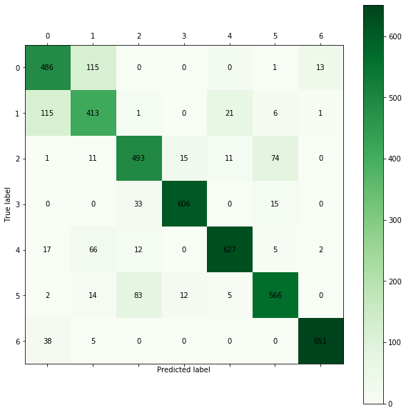

```python
# 显示混淆矩阵
cm_plot(Y_val, lgb_forest_val_pred).show()
```

### 4.3 导出测试数据预测

```python
# 导出函数

def write_to_submission_file(predicted_labels, out_file,
                             target='Cover_Type', index_label="Id", init_index=15121):
    predicted_df = pd.DataFrame(predicted_labels,
                                index = np.arange(init_index,
                                                  predicted_labels.shape[0] + init_index),
                                columns=[target])
    predicted_df.to_csv(out_file, index_label=index_label)
```

```python
# 测试数据
test = pd.read_csv('data/test.csv', index_col='Id')
```

```python
# 去除掉不必要的特征
test.drop(rem,axis=1,inplace=True)
X_test = test.values
```

```python
# 导出随机森林分类模型预测结果
test_rf_forest_pred = first_forest.predict(X_test)
write_to_submission_file(test_rf_forest_pred, 'rf_forest_cover_type.csv')
```

```python
# 导出LightGBM分类模型预测结果
test_lgbm_forest_pred = lgb_clf.predict(X_test)
write_to_submission_file(test_lgbm_forest_pred, 'lgbm_forest_cover_type.csv')
```